# hw8

Tariq Anwar

April 16, 2016

```r
data = read.table("CH14PR14.txt",sep = '')
colnames(data)<- c ("Y","X1","X2","X3")

fit<- glm(Y ~ X1+X2+X3, family=binomial, data=data)
summary(fit)
```

```
##
## Call:
## glm(formula = Y ~ X1 + X2 + X3, family = binomial, data = data)
##
## Deviance Residuals:
##     Min       1Q   Median       3Q      Max
## -1.4037  -0.5637  -0.3352  -0.1542   2.9394
##
## Coefficients:
##             Estimate Std. Error z value Pr(>|z|)
## (Intercept) -1.17716    2.98242  -0.395  0.69307
## X1           0.07279    0.03038   2.396  0.01658 *
## X2          -0.09899    0.03348  -2.957  0.00311 **
## X3           0.43397    0.52179   0.832  0.40558
## ---
## Signif. codes:  0 '***' 0.001 '**' 0.01 '*' 0.05 '.' 0.1 ' ' 1
##
## (Dispersion parameter for binomial family taken to be 1)
##
##     Null deviance: 134.94  on 158  degrees of freedom
## Residual deviance: 105.09  on 155  degrees of freedom
## AIC: 113.09
##
## Number of Fisher Scoring iterations: 6
```

```r
# B = z(1-.10/2*g)= z(1-.10/2*2) = z(.975) = 1.960
l1<- .07279-1.960*(0.03038)
h1<- .07279+1.960*(0.03038)

##CI for b1
l11<-exp(30*l1)
h11<-exp(30*h1)

l2<- -.09899-1.960*(0.03348)
h2<- -.09899+1.960*(0.03348)

##CI for 30
l22<-exp(25*l2)
h22<-exp(25*h2)
```

CI= 1.4878855 <$\beta_1$ < 52.9868622

CI= 0.0163215 <$\beta_2$ < 0.4342087

#### Part b

Null Hypothesis: $\beta_3 = 0$ Alternate Hypothesis: $\beta_3 \neq 0$

$z^* = 0.43397/0.5279$

Decision Rule: z(1-.05/2) = z(.975) = 1.96

if $Z^* <= 1.96 conclude H_0$

$Z^* >= 1.96 conclude H_a$

```r
z<-0.43397/0.52179
z
```

```
## [1] 0.8316947
```

since z <= 1.96 we can conclude Null hypothesis is true

Hence we conclude that can remove X3

## Part C

```r
##Full Model
FM<-logLik(fit)

## Reduced Model
rm<-glm(Y ~ X1+X2, family=binomial, data=data)

summary(rm)
```

```
##
## Call:
## glm(formula = Y ~ X1 + X2, family = binomial, data = data)
##
## Deviance Residuals:
##     Min       1Q   Median       3Q      Max
## -1.4479  -0.5708  -0.3390  -0.1629   2.8430
##
## Coefficients:
##             Estimate Std. Error z value Pr(>|z|)
## (Intercept) -1.45778    2.91534  -0.500  0.61705
## X1           0.07787    0.02970   2.622  0.00873 **
## X2          -0.09547    0.03241  -2.946  0.00322 **
## ---
## Signif. codes:  0 '***' 0.001 '**' 0.01 '*' 0.05 '.' 0.1 ' ' 1
##
## (Dispersion parameter for binomial family taken to be 1)
##
##     Null deviance: 134.94  on 158  degrees of freedom
## Residual deviance: 105.80  on 156  degrees of freedom
## AIC: 111.8
##
## Number of Fisher Scoring iterations: 6
```

```r
RM<-logLik(rm)
```

Test Statistics is: $G^2=-2(RM-FM)$ = 0.7022111

For $\alpha=0.05$ we require $\chi^2 (.95;1) = 3.84$

Decision Rule $G^2 <= 3.84 conclude H_0$

$G^2 >= 3.84 conclude H_a$

Since test statictic is less than 3.84 we conclude that null hypothesis is true.

P value of the test is 0.4020.

It can be concluded form b and c that X3 is not relevant and hence can be dropped from the model.

## Part d

Null Hypothesis: $\beta_3 , \beta_4 , \beta_5 = 0$

Alternate Hypothesis: $\beta_3 \beta_4 , \beta_5 \neq 0$

```r
nm<-glm(Y ~ X1+X2+I(X2^2)+I(X1^2)+X1*X2, family=binomial, data=data)
#summary(nm)

NM<-logLik(nm)
anova(nm,test="Chisq")
```

```
## Analysis of Deviance Table
##
## Model: binomial, link: logit
##
## Response: Y
##
## Terms added sequentially (first to last)
##
##
##         Df Deviance Resid. Df Resid. Dev  Pr(>Chi)
## NULL                      158     134.94
## X1       1  18.6738       157     116.27 1.551e-05 ***
## X2       1  10.4716       156     105.80  0.001212 **
## I(X2^2)  1   0.9506       155     104.84  0.329565
## I(X1^2)  1   0.1388       154     104.71  0.709471
## X1:X2    1   0.4445       153     104.26  0.504938
## ---
## Signif. codes:  0 '***' 0.001 '**' 0.01 '*' 0.05 '.' 0.1 ' ' 1
```

For $\alpha=0.05$ we require $\chi^2 (.95;3) = 7.81$

Decision Rule if $G^2 <= 7.81 conclude H_0$

iff $G^2 >= 7.81 conclude H_a$

Since test statictic is less than 7.81 we conclude that null hypothesis is true.

P-value of test is 0.6744.

## Problem2

```r
#part a
library(MASS)
Null = lm( Y ~ 1, family=binomial,data=data)
full<-glm(Y ~ X1+X2+X3+I(X1^2)+I(X2^2)+X1*X2, family=binomial, data=data)

addterm( Null, scope = full, test="F" )
```

```
## Single term additions
##
## Model:
## Y ~ 1
##         Df Sum of Sq    RSS     AIC F Value     Pr(F)
## <none>               20.377 -324.66
## X1       1   2.41219 17.965 -342.69 21.0805 8.975e-06 ***
## X2       1   2.62719 17.750 -344.61 23.2375 3.354e-06 ***
## X3       1   0.26197 20.115 -324.72  2.0447    0.1547
## I(X1^2)  1   2.47628 17.901 -343.26 21.7180 6.698e-06 ***
## I(X2^2)  1   2.19485 18.183 -340.78 18.9518 2.408e-05 ***
## ---
## Signif. codes:  0 '***' 0.001 '**' 0.01 '*' 0.05 '.' 0.1 ' ' 1
```

```r
NewMod = update( Null, .~. +X2 )
addterm( NewMod, scope = full, test="F" )
```

```
## Single term additions
##
## Model:
## Y ~ X2
##         Df Sum of Sq    RSS     AIC F Value    Pr(F)
## <none>               17.750 -344.61
## X1       1   0.79558 16.955 -349.90  7.3201 0.007577 **
## X3       1   0.11788 17.632 -343.67  1.0429 0.308724
## I(X1^2)  1   0.85965 16.890 -350.50  7.9397 0.005463 **
## I(X2^2)  1   0.77763 16.973 -349.73  7.1475 0.008306 **
## ---
## Signif. codes:  0 '***' 0.001 '**' 0.01 '*' 0.05 '.' 0.1 ' ' 1
```

```r
NewMod = update( NewMod, .~. +I(X1^2))
addterm( NewMod, scope = full, test="F" )
```

```
## Single term additions
##
## Model:
## Y ~ X2 + I(X1^2)
##         Df Sum of Sq    RSS     AIC F Value    Pr(F)
## <none>               16.890 -350.50
## X1       1   0.15028 16.740 -349.92  1.3914 0.239970
## X3       1   0.03848 16.852 -348.86  0.3539 0.552773
## I(X2^2)  1   0.86175 16.029 -356.83  8.3333 0.004449 **
## ---
## Signif. codes:  0 '***' 0.001 '**' 0.01 '*' 0.05 '.' 0.1 ' ' 1
```

```r
NewMod = update( NewMod, .~. +I(X2^2) )
addterm( NewMod, scope = full, test="F" )
```

```
## Single term additions
##
## Model:
## Y ~ X2 + I(X1^2) + I(X2^2)
##        Df Sum of Sq    RSS     AIC F Value  Pr(F)
## <none>              16.029 -356.83
## X1      1  0.035892 15.993 -355.19 0.34561 0.5575
## X3      1  0.084612 15.944 -355.67 0.81724 0.3674
```

```r
##########################################################
```

Step 1: X2 enters the model

step 2: X1^2 enters the model

Step 3: X2^2 enters the model

# part b

```
## Single term deletions
##
## Model:
## Y ~ X1 + X2 + X3 + I(X1^2) + I(X2^2)
##         Df Deviance    AIC F value   Pr(F)
## <none>       103.71 115.71
## X1       1   104.02 114.02  0.4658 0.49598
## X2       1   106.07 116.07  3.4889 0.06369 .
## X3       1   104.71 114.71  1.4721 0.22689
## I(X1^2)  1   103.85 113.85  0.2070 0.64976
## I(X2^2)  1   105.03 115.03  1.9569 0.16387
## ---
## Signif. codes:  0 '***' 0.001 '**' 0.01 '*' 0.05 '.' 0.1 ' ' 1
```

```
## Single term deletions
##
## Model:
## Y ~ X1 + X2 + X3 + I(X2^2)
##         Df Deviance    AIC F value    Pr(F)
## <none>       103.85 113.85
## X1       1   110.22 118.22  9.4440 0.002506 **
## X2       1   106.12 114.12  3.3723 0.068228 .
## X3       1   104.84 112.84  1.4774 0.226039
## I(X2^2)  1   105.09 113.09  1.8458 0.176263
## ---
## Signif. codes:  0 '***' 0.001 '**' 0.01 '*' 0.05 '.' 0.1 ' ' 1
```

```
## Single term deletions
##
## Model:
## Y ~ X1 + X2 + I(X2^2)
##         Df Deviance    AIC F value     Pr(F)
## <none>       104.84 112.84
## X1       1   112.64 118.64 11.5261 0.0008717 ***
## X2       1   106.73 112.73  2.7863 0.0970906 .
## I(X2^2)  1   105.80 111.80  1.4054 0.2376436
## ---
## Signif. codes:  0 '***' 0.001 '**' 0.01 '*' 0.05 '.' 0.1 ' ' 1
```

```
## Single term deletions
##
## Model:
## Y ~ X1 + X2
##        Df Deviance    AIC F value     Pr(F)
## <none>      105.80 111.80
## X1      1   113.20 117.20  10.912 0.0011848 **
## X2      1   116.27 120.27  15.441 0.0001276 ***
## ---
## Signif. codes:  0 '***' 0.001 '**' 0.01 '*' 0.05 '.' 0.1 ' ' 1
```

Step 1: Drop X1^2 Step 3: Drop X3 Step 4: Drop X2^2

predictors remaining in the model are X1 and X2

It is different from part (a). Since it chooses X1 and X2 whereas there we got different predictors

### Part c and d

```r
##########################################
Null = lm( Y ~ 1, family=binomial,data=data)
full<-glm(Y ~ X1+X2+X3+I(X1^2)+I(X2^2)+X1*X2, family=binomial, data=data)
forward<-step(Null, scope = list( upper=full, lower=~1 ), direction = "forward", trace=FALSE)
formula(forward)
```

```
## Y ~ X2 + I(X1^2) + I(X2^2)
```

```r
#########################################
step(full,direction="backward",k=log(nrow(data)))
```

```
## Start:  AIC=138.45
## Y ~ X1 + X2 + X3 + I(X1^2) + I(X2^2) + X1 * X2
##
##           Df Deviance    AIC
## - I(X1^2)  1   103.00 133.41
## - X1:X2    1   103.71 134.12
## - X3       1   104.26 134.68
## - I(X2^2)  1   104.98 135.40
## <none>         102.97 138.45
##
## Step:  AIC=133.41
## Y ~ X1 + X2 + X3 + I(X2^2) + X1:X2
##
##           Df Deviance    AIC
## - X1:X2    1   103.85 129.19
## - X3       1   104.31 129.66
## - I(X2^2)  1   105.02 130.36
## <none>         103.00 133.41
##
## Step:  AIC=129.19
## Y ~ X1 + X2 + X3 + I(X2^2)
##
##           Df Deviance    AIC
## - X3       1   104.84 125.12
## - I(X2^2)  1   105.09 125.37
## - X2       1   106.12 126.40
## <none>         103.85 129.19
## - X1       1   110.22 130.49
##
## Step:  AIC=125.12
## Y ~ X1 + X2 + I(X2^2)
##
##           Df Deviance    AIC
## - I(X2^2)  1   105.80 121.00
## - X2       1   106.73 121.94
## <none>         104.84 125.12
## - X1       1   112.64 127.85
##
## Step:  AIC=121
## Y ~ X1 + X2
##
##        Df Deviance    AIC
## <none>      105.80 121.00
## - X1    1   113.20 123.33
## - X2    1   116.27 126.41
```

```
##
## Call:  glm(formula = Y ~ X1 + X2, family = binomial, data = data)
##
## Coefficients:
## (Intercept)           X1           X2
##    -1.45778      0.07787     -0.09547
##
## Degrees of Freedom: 158 Total (i.e. Null);  156 Residual
## Null Deviance:       134.9
## Residual Deviance: 105.8     AIC: 111.8
```

According to AIC criterion the predictors choosen are same as that of part a. According to SBc criterion the predictors choosen are same as that of part b.

### Question 3

#### Part a

```
## ResourceSelection 0.2-6   2016-02-15
```

```
##                      yhat0      yhat1 y0 y1
## [0.00412,0.0164] 19.796921  0.2030794 20  0
## (0.0164,0.0398]  19.460141  0.5398591 19  1
## (0.0398,0.061]   18.990879  1.0091209 20  0
## (0.061,0.0998]   18.448525  1.5514749 18  2
## (0.0998,0.149]   16.687088  2.3129120 18  1
## (0.149,0.201]    16.558490  3.4415100 12  8
## (0.201,0.297]    15.319875  4.6801250 18  2
## (0.297,0.914]     9.738081 10.2619188 10 10
```

#### Part b

```r
htest<-hoslem.test(data$Y, fitted(mod3), g=8)
htest
```

```
##
##  Hosmer and Lemeshow goodness of fit (GOF) test
##
## data:  data$Y, fitted(mod3)
## X-squared = 11.97, df = 6, p-value = 0.06263
```

Null Hypothesis $H_0 : E({Y})=[1+exp(-\beta_0-\beta_1X_1-\beta_2X_2-\beta_3X_3)]^{-1}$

Alternate Hypothesis: $H_0 : E({Y})\neq[1+exp(-\beta_0-\beta_1X_1-\beta_2X_2-\beta_3X_3)]^{-1}$

$\chi^2 =11.97$

since chi square is less than chisquare(.95;6)=12.59 we conclude H0 otherwise Ha

Hence H0 is true

P value 0.062

#### Part c

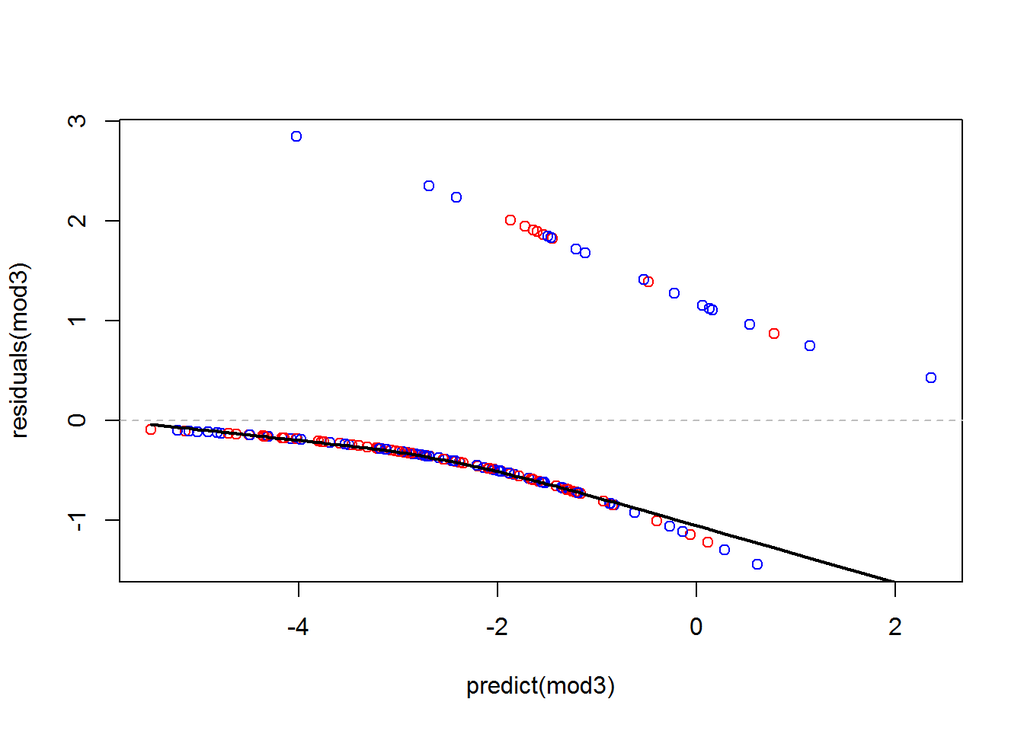

```r
 plot(predict(mod3),residuals(mod3),col=c("blue","red"))
abline(h=0,lty=2,col="grey")
lines(lowess(predict(mod3),residuals(mod3)),col="black",lwd=2)
```

```r
fit<- glm(Y ~ X1+X2+X3, family=binomial, data=data)
newOrings <- data.frame(X1=65, X2=50,X3=0)
newOrings.predictLink <- predict(fit,newdata=newOrings ,se.fit=T, type="link")
L <- newOrings.predictLink$fit - qnorm(1-0.05/(2*2))*newOrings.predictLink$se
U <- newOrings.predictLink$fit + qnorm(1-0.05/(2*2))*newOrings.predictLink$se
ci = c(L,U)
ci
```

```
##          1          1
## -2.2954113 -0.4951142
```

```r
table(theProbs>.5, data$Y)
```

```
##
##           0   1
##   FALSE 130  18
##   TRUE    5   6
```

```r
table(theProbs>.10, data$Y)
```

```
##
##          0  1
##   FALSE 80  3
##   TRUE  55 21
```

```r
table(theProbs>.15, data$Y)
```

```
##
##          0  1
##   FALSE 97  4
##   TRUE  38 20
```

```r
table(theProbs>.20, data$Y)
```

```
##
##           0   1
##   FALSE 113  10
##   TRUE   22  14
```

#### part c

```r
train <- sample(x=1:nrow(data), size=nrow(data)/4)
fit.train <- glm(Y ~., family=binomial, data=data[train,])

# calculate predicted probabilities on the same training set
scores <- predict(fit.train, newdata=data[train,], type="response")

# compare predicted probabilities to labels, for varying probability cutoffs
pred <- prediction(scores, labels=data[train,]$Y )
perf <- performance(pred, "tpr", "fpr")

# plot the ROC curve
plot(perf, colorize=F, main="In-sample ROC curve")

# print out the area under the curve
unlist(attributes(performance(pred, "auc"))$y.values)
```

```
## [1] 0.78125
```

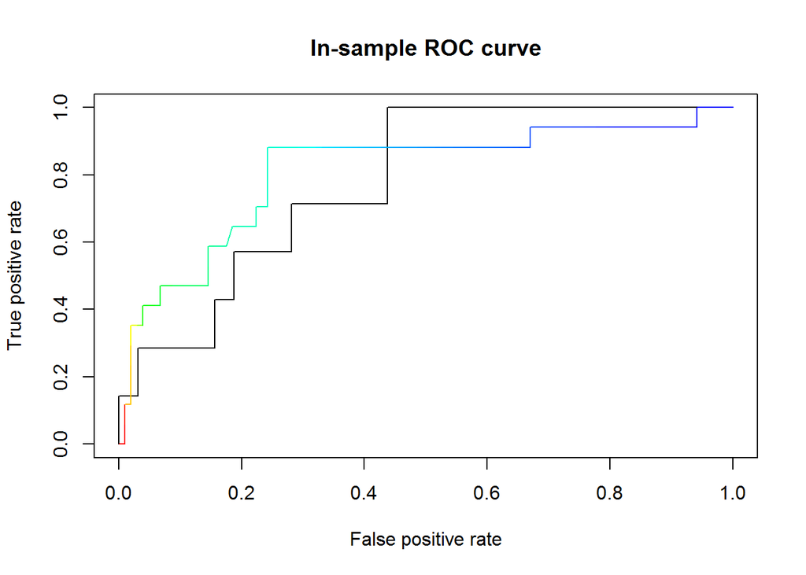

```r
# --------------Evalate the predictive ability on the validation set------------
# make prediction on the validation dataset
scores <- predict(fit.train, newdata=data[-train,], type="response")
pred <- prediction( scores, labels=data[-train,]$Y )
perf <- performance(pred, "tpr", "fpr")

# overlay the line for the ROC curve
plot(perf, colorize=T, add=TRUE)
```

```r
# print out the area under the curve
unlist(attributes(performance(pred, "auc"))$y.values)
```

```
## [1] 0.8095374
```

### part d

The reliability of the prediction error rate observed in the model-building data set is examined by applying the chosen prediction rule to a validation data set. If the new prediction error rate is about the same as that for the model-building data set, then the latter gives a reliable indication of the predictive ability of the fitted logistic regression model and the chosen prediction rule. If the new data lead to a considerably higher prediction error rate, then the fitted logistic regression model and the chosen prediction rule do not predict new observations as well as originally indicated

### Problem 5

#### part a

```r
ldata<- matrix(data = c(35,35,40,40,45,45,50,50,55,55,60,60,22,20,28,31,37,38,41,39,34,37,27,20), nrow=12 , ncol=2)

ldata<-data.frame(ldata)
colnames(ldata)<- c("X","Y")

fit2 <- lm(ldata$Y ~ ldata$X + I(ldata$X^2))
fit2
```

```
##
## Call:
## lm(formula = ldata$Y ~ ldata$X + I(ldata$X^2))
##
## Coefficients:
##  (Intercept)       ldata$X  I(ldata$X^2)
##    -215.6179       10.5368       -0.1089
```

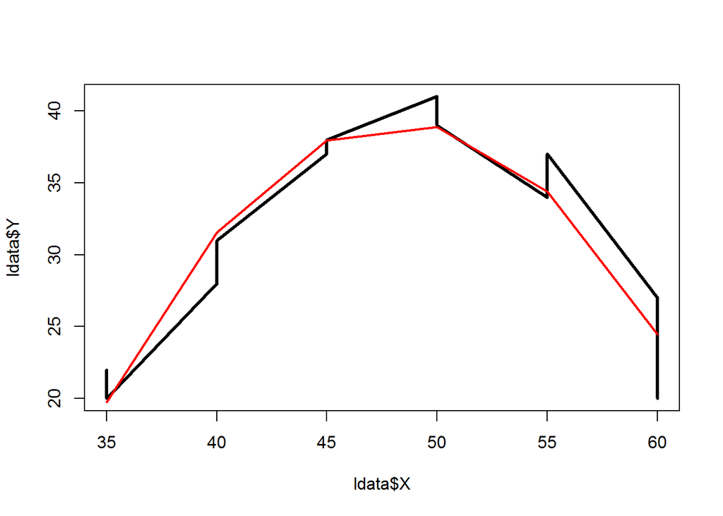

```r
plot(ldata$X, ldata$Y, type="l", lwd=3)
points(ldata$X, predict(fit2), type="l", col="red", lwd=2)
```

The quadratic function is good fit here.

#### part b

```r
mean_x<- mean(ldata$X)
X_max= mean_x-(.5*(as.numeric(fit2$coef[2]))/as.numeric(fit2$coef[3]) )
X_max
```

```
## [1] 95.86557
```

#### part c

```r
library(boot)
fit <- fitted(fit2)
e <- residuals(fit2)
x <- model.matrix(fit2)
boot.fixed <- function(data, indices, maxit=20){
y <- fit + e[indices]
mod <- rlm(y ~ x-1, maxit=maxit)
coefficients(mod)}


fix.boot <- boot(ldata, boot.fixed, 1000, maxit=100)
fix.boot
```

```
##
## ORDINARY NONPARAMETRIC BOOTSTRAP
##
##
## Call:
## boot(data = ldata, statistic = boot.fixed, R = 1000, maxit = 100)
##
##
## Bootstrap Statistics :
##         original        bias    std. error
## t1* -203.3401528 -12.936520994 23.65491693
## t2*    9.9769304   0.592488923  1.01836150
## t3*   -0.1025914  -0.006673702  0.01066769
```

### Part d

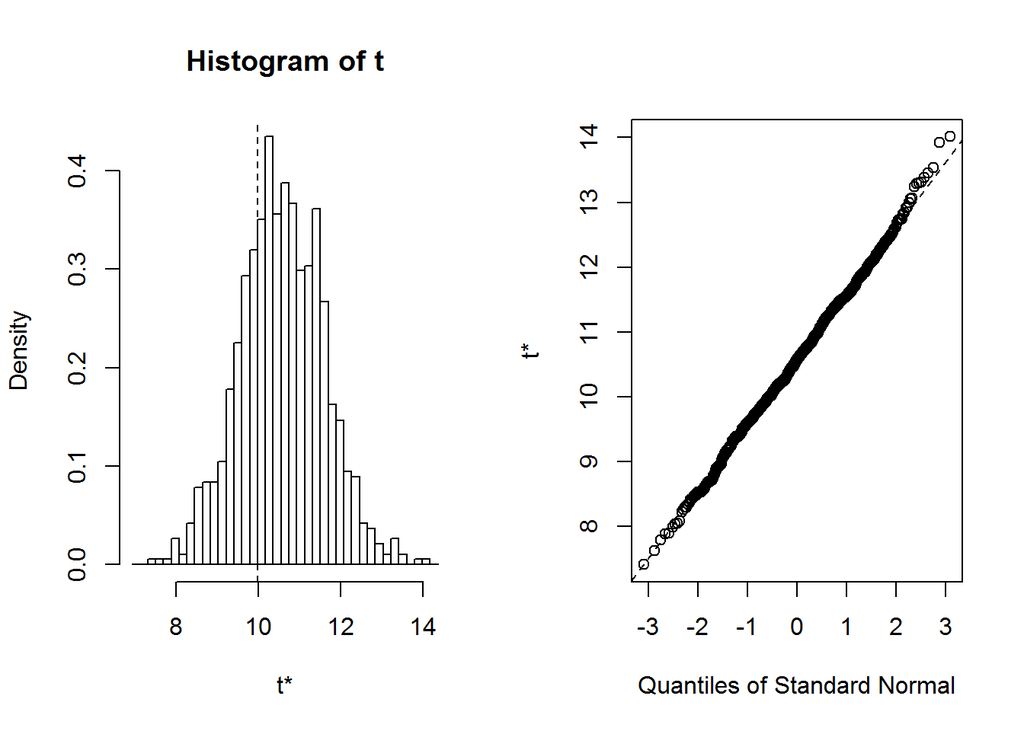

```r
plot(fix.boot,index=2)
```

yes the histogram is normally distributed

### Part e

```r
boot.ci(boot.out = fix.boot, conf = 0.90,type = c("norm", "perc", "bca"),
index = 2)
```

```
## BOOTSTRAP CONFIDENCE INTERVAL CALCULATIONS
## Based on 1000 bootstrap replicates
##
## CALL :
## boot.ci(boot.out = fix.boot, conf = 0.9, type = c("norm", "perc",
##     "bca"), index = 2)
##
## Intervals :
## Level      Normal             Percentile            BCa
## 90%   ( 7.709, 11.059 )   ( 8.855, 12.224 )   ( 7.855, 11.108 )
## Calculations and Intervals on Original Scale
## Some BCa intervals may be unstable
```